# Explore and Summarize Data

## Description of Red Wine dataset

For this project, I used a data set on red wines quality.The guiding question for this analysis is “Which chemical properties influence the quality of red wines?”. So my main objective is to explore the chemical properties that tend to influence the quality of red wines. This tidy data set contains 1,599 red wines with 11 variables on the chemical properties of the wine. At least 3 wine experts rated the quality of each wine, providing a rating between 0 (very bad) and 10 (very excellent).

To find out more about the article which describes the variables and how the data was collected. https://s3.amazonaws.com/udacity-hosted-downloads/ud651/wineQualityInfo.txt

The data set link:https://s3.amazonaws.com/udacity-hosted-downloads/ud651/wineQualityReds.csv.

### Dataset Summary

```
## 'data.frame':    1599 obs. of  13 variables:
##  $ X                   : int  1 2 3 4 5 6 7 8 9 10 ...
##  $ fixed.acidity       : num  7.4 7.8 7.8 11.2 7.4 7.4 7.9 7.3 7.8 7.5 ...
##  $ volatile.acidity    : num  0.7 0.88 0.76 0.28 0.7 0.66 0.6 0.65 0.58 0.5 ...
##  $ citric.acid         : num  0 0 0.04 0.56 0 0 0.06 0 0.02 0.36 ...
##  $ residual.sugar      : num  1.9 2.6 2.3 1.9 1.9 1.8 1.6 1.2 2 6.1 ...
##  $ chlorides           : num  0.076 0.098 0.092 0.075 0.076 0.075 0.069 0.065 0.073 0.071 ...
##  $ free.sulfur.dioxide : num  11 25 15 17 11 13 15 15 9 17 ...
##  $ total.sulfur.dioxide: num  34 67 54 60 34 40 59 21 18 102 ...
##  $ density             : num  0.998 0.997 0.997 0.998 0.998 ...
##  $ pH                  : num  3.51 3.2 3.26 3.16 3.51 3.51 3.3 3.39 3.36 3.35 ...
##  $ sulphates           : num  0.56 0.68 0.65 0.58 0.56 0.56 0.46 0.47 0.57 0.8 ...
##  $ alcohol             : num  9.4 9.8 9.8 9.8 9.4 9.4 9.4 10 9.5 10.5 ...
##  $ quality             : int  5 5 5 6 5 5 5 7 7 5 ...
```

There are 1,599 observation with total 13 variables. There is an unique identifier named ‘X’ The ‘X’ and ‘quality’ variables have integer values. All the other variables are numeric values.

### Summary of the Variables in the Red Wine Dataset

```
##        X          fixed.acidity   volatile.acidity  citric.acid
##  Min.   :   1.0   Min.   : 4.60   Min.   :0.1200   Min.   :0.000
##  1st Qu.: 400.5   1st Qu.: 7.10   1st Qu.:0.3900   1st Qu.:0.090
##  Median : 800.0   Median : 7.90   Median :0.5200   Median :0.260
##  Mean   : 800.0   Mean   : 8.32   Mean   :0.5278   Mean   :0.271
##  3rd Qu.:1199.5   3rd Qu.: 9.20   3rd Qu.:0.6400   3rd Qu.:0.420
##  Max.   :1599.0   Max.   :15.90   Max.   :1.5800   Max.   :1.000
##  residual.sugar     chlorides       free.sulfur.dioxide
##  Min.   : 0.900   Min.   :0.01200   Min.   : 1.00
##  1st Qu.: 1.900   1st Qu.:0.07000   1st Qu.: 7.00
##  Median : 2.200   Median :0.07900   Median :14.00
##  Mean   : 2.539   Mean   :0.08747   Mean   :15.87
##  3rd Qu.: 2.600   3rd Qu.:0.09000   3rd Qu.:21.00
##  Max.   :15.500   Max.   :0.61100   Max.   :72.00
##  total.sulfur.dioxide    density             pH          sulphates
##  Min.   :  6.00       Min.   :0.9901   Min.   :2.740   Min.   :0.3300
##  1st Qu.: 22.00       1st Qu.:0.9956   1st Qu.:3.210   1st Qu.:0.5500
##  Median : 38.00       Median :0.9968   Median :3.310   Median :0.6200
##  Mean   : 46.47       Mean   :0.9967   Mean   :3.311   Mean   :0.6581
##  3rd Qu.: 62.00       3rd Qu.:0.9978   3rd Qu.:3.400   3rd Qu.:0.7300
##  Max.   :289.00       Max.   :1.0037   Max.   :4.010   Max.   :2.0000
##     alcohol         quality
##  Min.   : 8.40   Min.   :3.000
##  1st Qu.: 9.50   1st Qu.:5.000
##  Median :10.20   Median :6.000
##  Mean   :10.42   Mean   :5.636
##  3rd Qu.:11.10   3rd Qu.:6.000
##  Max.   :14.90   Max.   :8.000
```

```
##    Min. 1st Qu.  Median    Mean 3rd Qu.    Max.
##   3.000   5.000   6.000   5.636   6.000   8.000
```

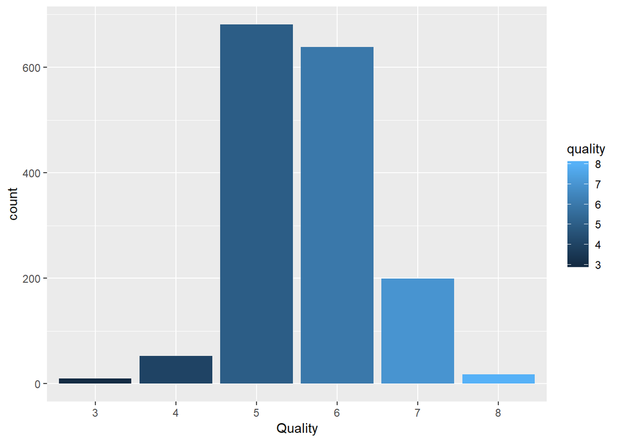

A basic plot about the quality of the red wines. The “quality” data points lie in the range of from 3 to 8.The “mean” is about 5.636.

# Univariate Analysis

## Univariate Plots Section

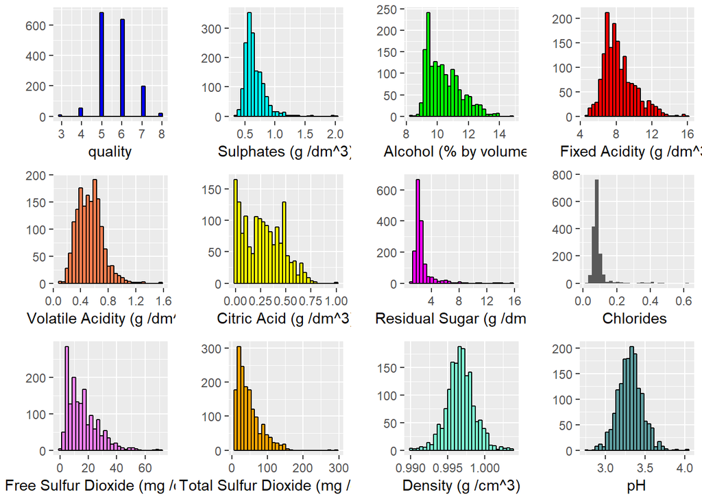

### Wine “Quality” Analysis

The entire wine quality is categorized in the range from 3 to 8.The most common values are 5 and 6 bucket.The least common values are 3-4 and 7-8 range bucket. To make this easier to understand, we can bin these values in a range bucket. I created an additional variable in the red wine data set called ‘rating’. The range is computed as shown below.

0 - 4 : poor 5 - 6 : good 7 - 10 : ideal

```
##  Poor  Good Ideal
##    63  1319   217
```

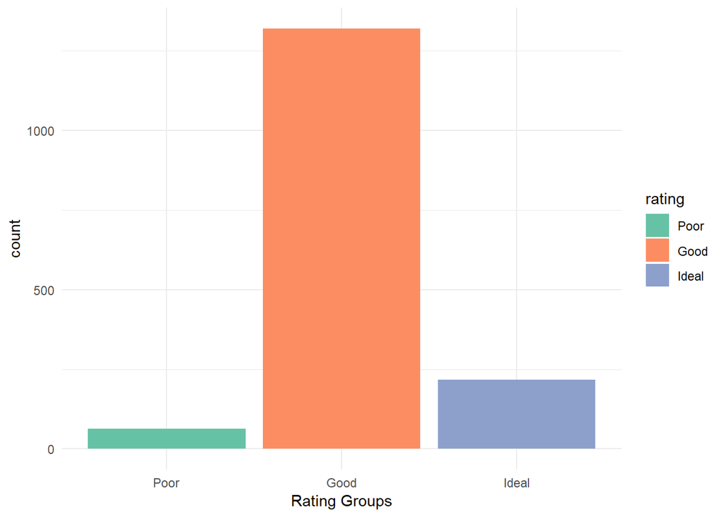

### Summary of the rating:

```
##  Poor  Good Ideal
##    63  1319   217
```

### Calculate another variable called “Total Acidity”" and add it to the dataframe

To calculate the sum of all “acids”" in the red wines data frame. Once I have that sum value I can add the “new” variable to the data frame. The first few values of the new ‘total acidity’ as shown below.

```
##  [1]  8.100  8.680  8.600 12.040  8.100  8.060  8.560  7.950  8.400  8.360
## [11]  7.360  8.360  6.215  8.700  9.700  9.710  9.340  8.940  8.070  8.730
```

### Transforming Data using a Log 10 scale for better reprsenting the long tailed data.

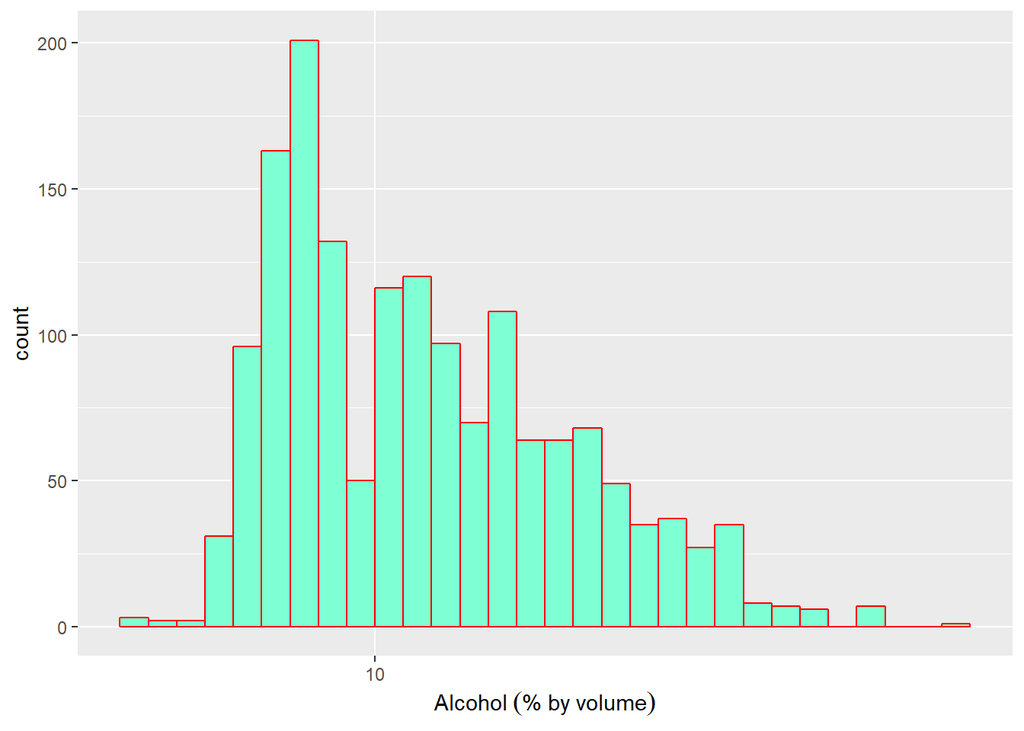

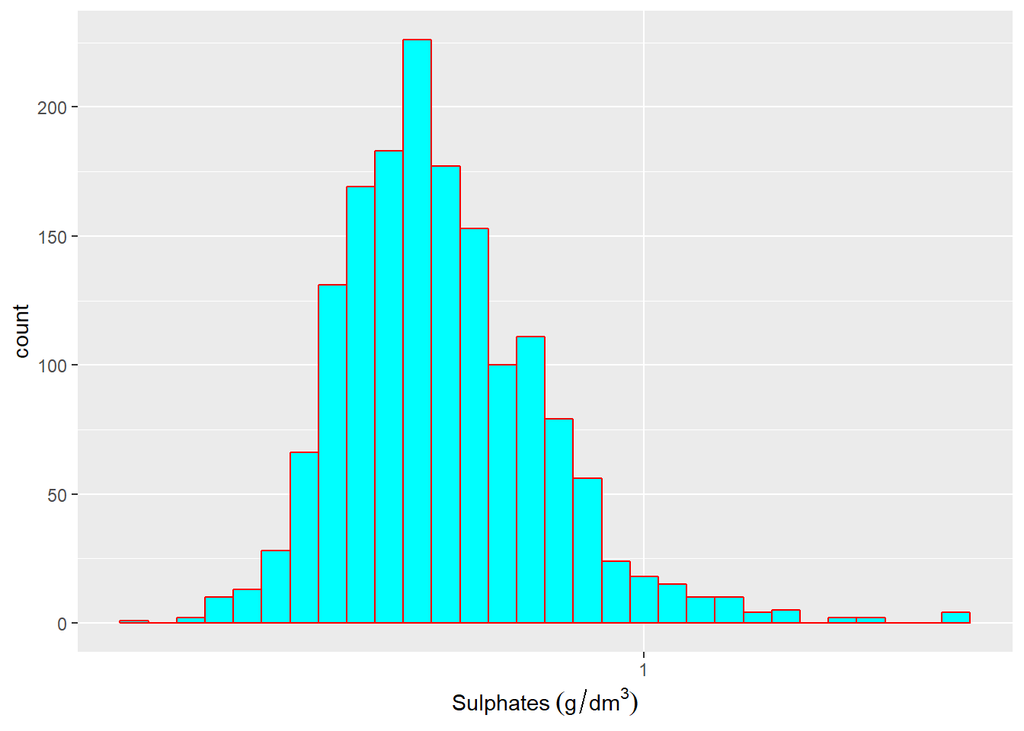

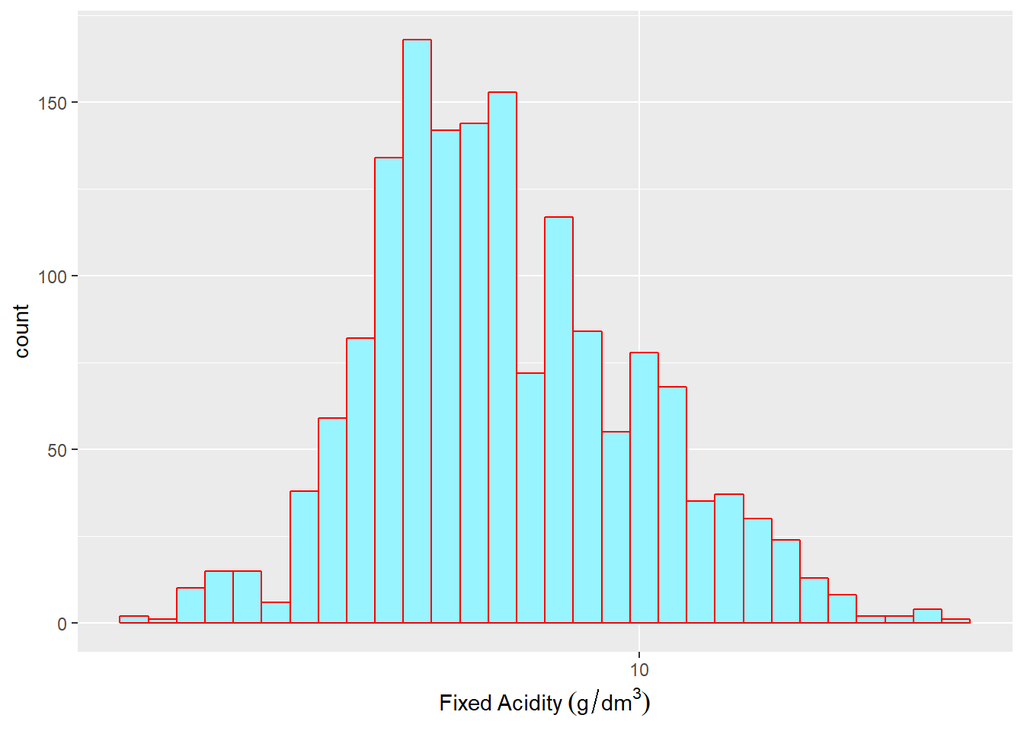

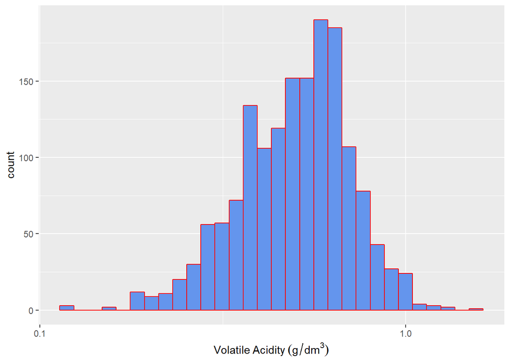

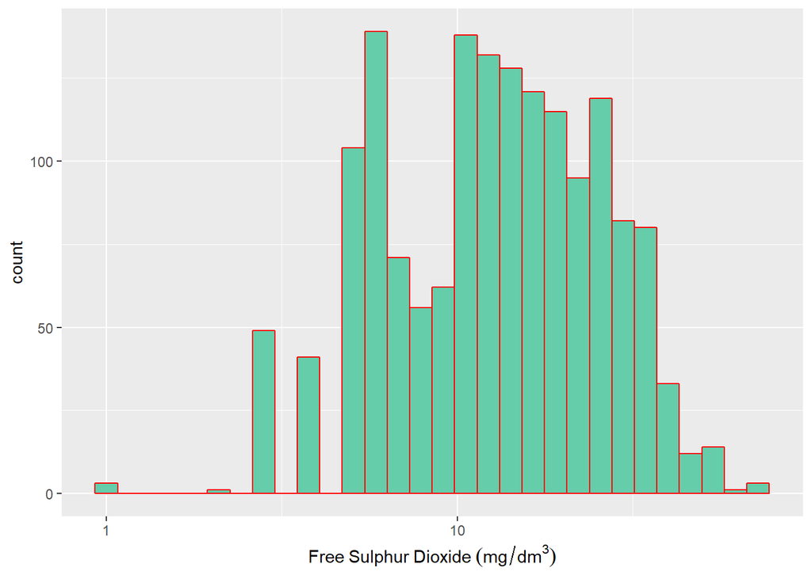

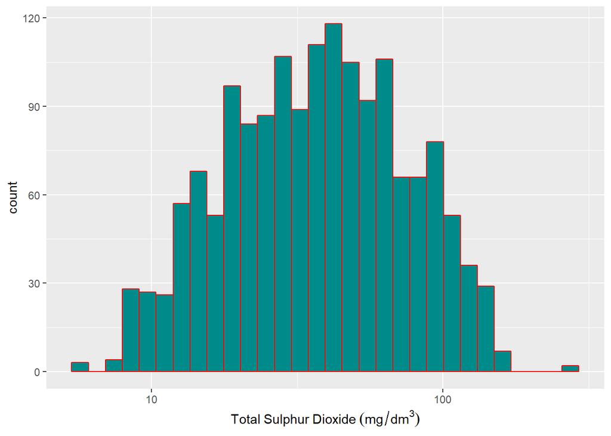

After the transformation, i.e using the log 10 transformation, it appears that the plots are now close to normally distributed.

In our plots earlier we noticed “zero” values for “citric.acid” variables"

### Total number of “zero” values in “citric.acid” variable.

```
## [1] 132
```

There are about 132 observations that have zero values in the citric.acid variable.

### Plot for Citric Acid with 95 th percentile

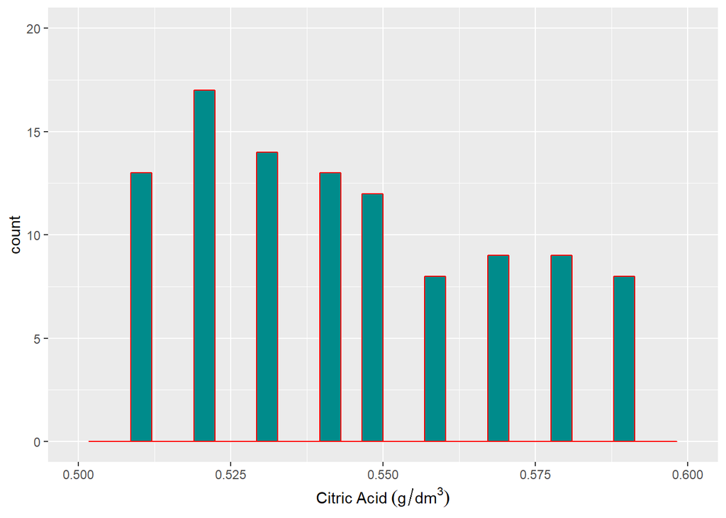

### Pattern investigation between variables.

From the graphs earlier, I think we may have some pattern between residual.sugar and chlorides. These variables also have outliers. Lets start by using a plot up to 95 th percentile.That would remove the extreme outliers

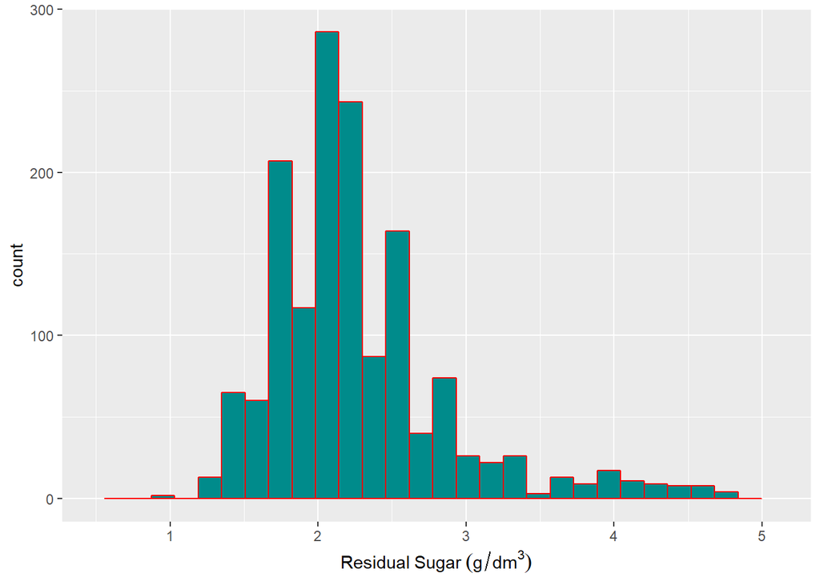

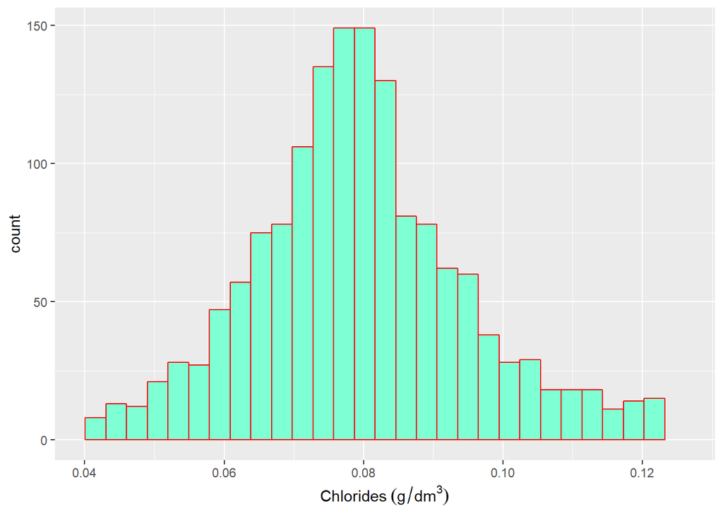

Using up to the 95 th percentile values, notice that the “chlorides” plot is normally distributed.

For the residual.sugar plot, it is somewhat close to being a normally distributed plot.The range is from 1 to about 4.8.There are still some outliers. They are however not extreme from my understanding.

### Is there a Correlation between residual.sugar and chlorides?

```
##
##  Pearson's product-moment correlation
##
## data:  df_rw$residual.sugar and df_rw$chlorides
## t = 2.2257, df = 1597, p-value = 0.02617
## alternative hypothesis: true correlation is not equal to 0
## 95 percent confidence interval:
##  0.006606405 0.104346223
## sample estimates:
##        cor
## 0.05560954
```

It appears there is not much of a correlation between the two variables.

## Univariate Analysis Questions

### What is the structure of your dataset?

```
## 'data.frame':    1599 obs. of  15 variables:
##  $ X                   : int  1 2 3 4 5 6 7 8 9 10 ...
##  $ fixed.acidity       : num  7.4 7.8 7.8 11.2 7.4 7.4 7.9 7.3 7.8 7.5 ...
##  $ volatile.acidity    : num  0.7 0.88 0.76 0.28 0.7 0.66 0.6 0.65 0.58 0.5 ...
##  $ citric.acid         : num  0 0 0.04 0.56 0 0 0.06 0 0.02 0.36 ...
##  $ residual.sugar      : num  1.9 2.6 2.3 1.9 1.9 1.8 1.6 1.2 2 6.1 ...
##  $ chlorides           : num  0.076 0.098 0.092 0.075 0.076 0.075 0.069 0.065 0.073 0.071 ...
##  $ free.sulfur.dioxide : num  11 25 15 17 11 13 15 15 9 17 ...
##  $ total.sulfur.dioxide: num  34 67 54 60 34 40 59 21 18 102 ...
##  $ density             : num  0.998 0.997 0.997 0.998 0.998 ...
##  $ pH                  : num  3.51 3.2 3.26 3.16 3.51 3.51 3.3 3.39 3.36 3.35 ...
##  $ sulphates           : num  0.56 0.68 0.65 0.58 0.56 0.56 0.46 0.47 0.57 0.8 ...
##  $ alcohol             : num  9.4 9.8 9.8 9.8 9.4 9.4 9.4 10 9.5 10.5 ...
##  $ quality             : int  5 5 5 6 5 5 5 7 7 5 ...
##  $ rating              : Ord.factor w/ 3 levels "Poor"<"Good"<..: 2 2 2 2 2 2 2 3 3 2 ...
##  $ total.acidity       : num  8.1 8.68 8.6 12.04 8.1 ...
```

### What is/are the main feature(s) of interest in your dataset?

The guiding question for this analysis is “Which chemical properties influence the quality of red wines?

### Are there any unique features of the dataset?

From the graphs, I think the “Citric acid” is a unique feature. There are many “zero” values as compared to the other numeric variables.

### Plots Distribution analysis and Outliers in the Red Wine Dataset

Density and pH seems normally distributed with few outliers.

Residual sugar and Chloride seems to have extreme outliers.

Fixed and volatile acidity, total and free sulfur dioxides, alcohol and sulphates seem to be long-tailed with outliers present.

Citric acid has large number of zero values. One possible reason could be because of insufficient number of observations.

### Did you create any new variables from existing variables in the dataset?

A new variable called “rating” was created. This variable is an ordered factor. There are three levels. They have been classified as ‘poor’, ‘good’ and ‘ideal’.

Additionally another variable called “total.acidity” was also added to the original data frame. This variable is for the sum of all acids.

### Of the features you investigated, were there any unusual distributions? Did you perform any operations on the data to tidy, adjust, or change the form of the data? If so, why did you do this?

I log-transformed the right skewed alcohol,sulphates,fixed.acidity,volatile.acidity,free.sulfur.dioxide and total.sulphur.dioxide

Some of the values also have outliers. Applying the log transformation reduced the number of outliers. The log 10 transformation also made the plots into normal distribution.

## Bivariate Analysis

### Bivariate Plots

To compare if each variable is correlated with another, lets compare the variables with a correlation table.

```
##
## ---------------------------------------------------------------------------
##           &nbsp;            fixed.acidity   volatile.acidity   citric.acid
## -------------------------- --------------- ------------------ -------------
##     **fixed.acidity**             1             -0.2561        **0.6717**
##
##    **volatile.acidity**        -0.2561             1           **-0.5525**
##
##      **citric.acid**         **0.6717**       **-0.5525**           1
##
##     **residual.sugar**         0.1148           0.001918         0.1436
##
##       **chlorides**            0.09371           0.0613          0.2038
##
##  **free.sulfur.dioxide**       -0.1538          -0.0105         -0.06098
##
##  **total.sulfur.dioxide**      -0.1132          0.07647          0.03553
##
##        **density**            **0.668**         0.02203        **0.3649**
##
##           **pH**             **-0.683**          0.2349        **-0.5419**
##
##       **sulphates**             0.183            -0.261        **0.3128**
##
##        **alcohol**            -0.06167          -0.2023          0.1099
##
##        **quality**             0.1241         **-0.3906**        0.2264
##
##     **total.acidity**        **0.9964**         -0.2044        **0.6904**
## ---------------------------------------------------------------------------
##
## Table: Table continues below
##
##
## ------------------------------------------------------------------------------
##           &nbsp;            residual.sugar   chlorides    free.sulfur.dioxide
## -------------------------- ---------------- ------------ ---------------------
##     **fixed.acidity**           0.1148        0.09371           -0.1538
##
##    **volatile.acidity**        0.001918        0.0613           -0.0105
```

[output cut: 74 more lines]

```
##
##  **total.sulfur.dioxide**    0.04295       -0.2057       -0.1851       -0.09628
##
##        **density**            0.1485     **-0.4962**     -0.1749      **0.6756**
##
##           **pH**             -0.1966       0.2056       -0.05773      **-0.6835**
##
##       **sulphates**             1          0.09359       0.2514         0.1816
##
##        **alcohol**           0.09359          1        **0.4762**      -0.06667
##
##        **quality**            0.2514     **0.4762**         1           0.1038
##
##     **total.acidity**         0.1816      -0.06667       0.1038            1
## -----------------------------------------------------------------------------------
```

It appears that Volatile acidity has a positive correlation with pH. On the other hand, increase in pH makes the basicity increase. This is a contradiction in this observation.

Density and Fixed Acidity are strongly correlated.

Alcohol and density are negatively correlated. This is logical because density of alcohol is less that compared to water.

Lets dive deeper with Box plots between two variables.

### Box Plots

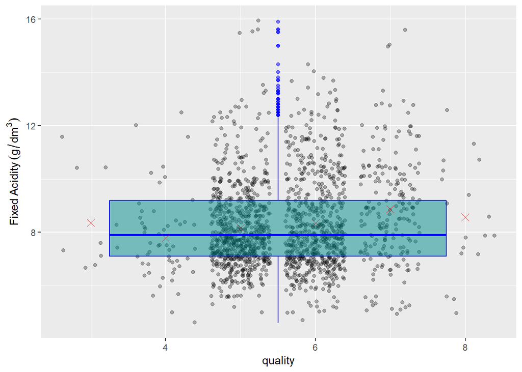

There is not much correlation between Fixed Acidity and Quality.

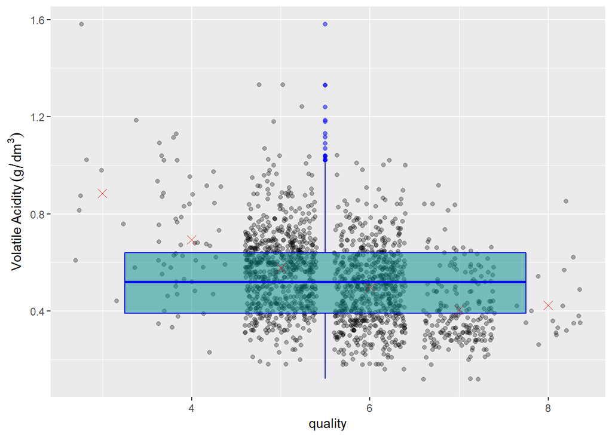

From this plot we can see that Volatile acid is negatively correlated to the quality of the wine. The higher the volatile acid level the quality of the wine decreases.

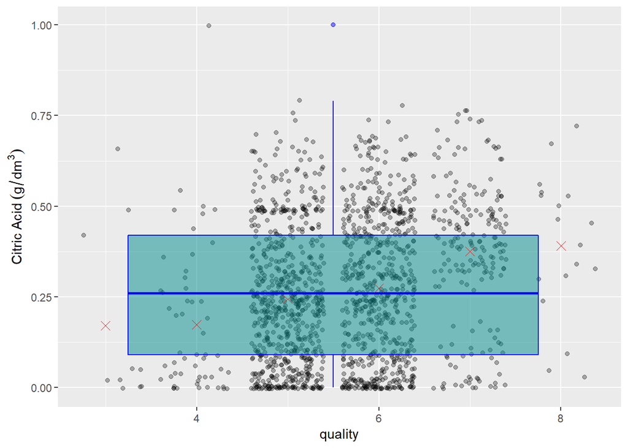

From this plot, we can see that Citric acid is positively correlated to Wine Quality.

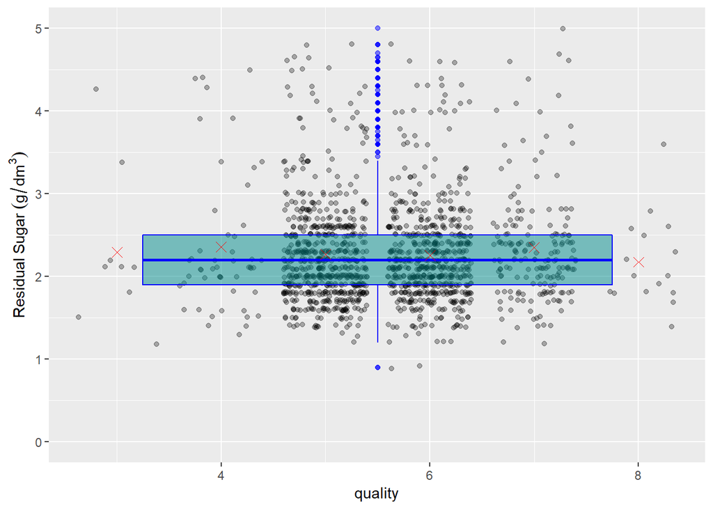

From this plot we can see that Residual Sugar does not have much correlation with he Quality of the Wine. For quality values the mean values of residual sugar as similar across values.

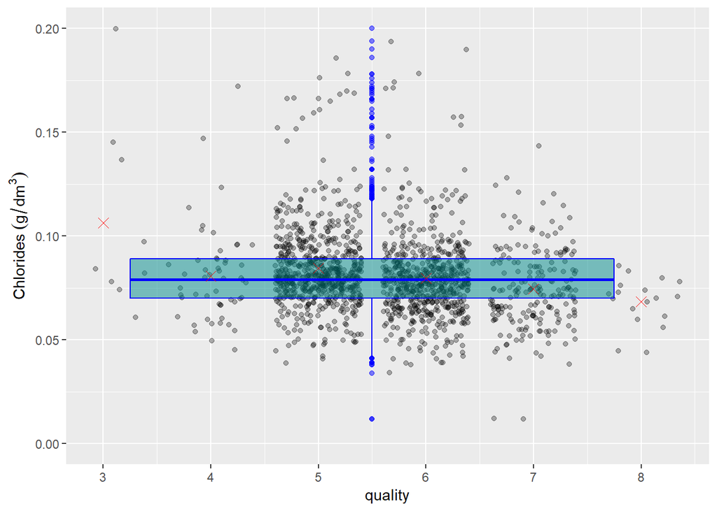

There is a slight negative correlation between Chlorides with quality If there are lower counts of Chloride the result seems to be better wines.

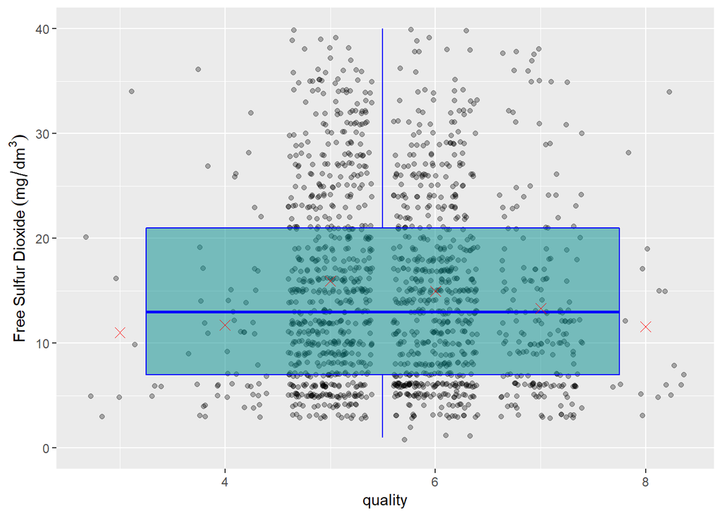

The mean values seems to be like a sine wave. It appears that very low amounts of Free Sulphur Dioxide results in bad wine. A small increase of Free sulphur slightly increases the quality.

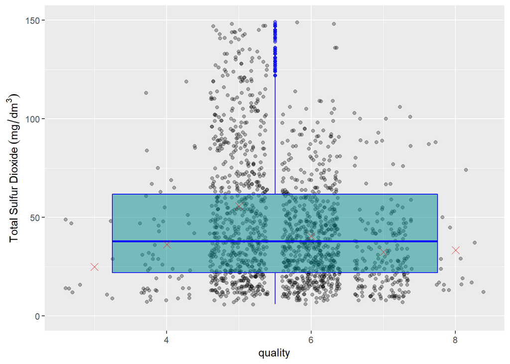

The same pattern as Free sulphur dioxide above can be observed here. It appears that low amounts of total sulphur dioxide results in bad wine. A small increase of total sulphur slightly increases the quality.

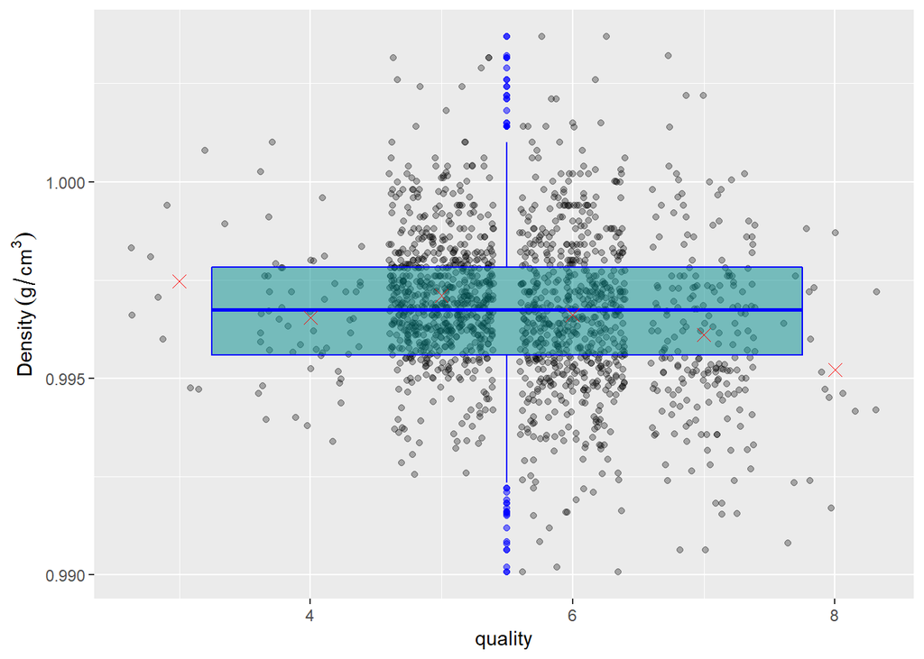

From this plot, we can see that good wine appear to have low density.One possible reason for this could be that they have higher alcohol content which causes this lower density.

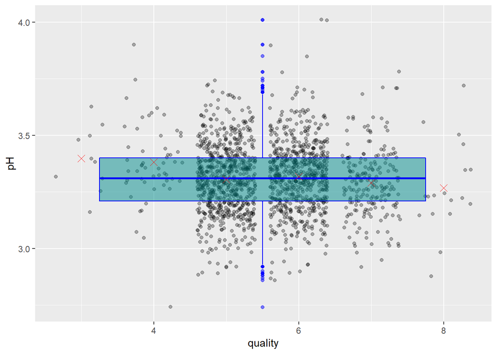

From this plot we can notice that good wines seems to have lower pH level. Lower pH means more acidic.

Also notice there are a few outliers in this plot. We can plot and compare the different acid properties.

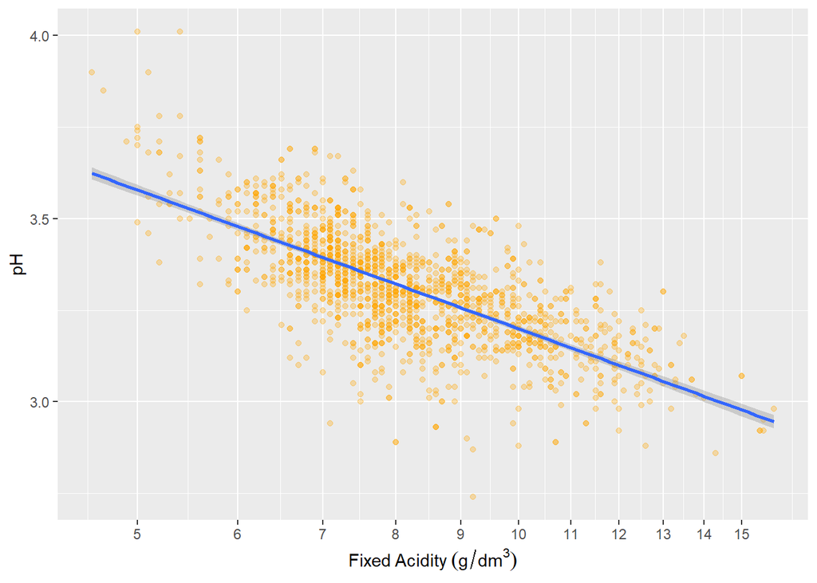

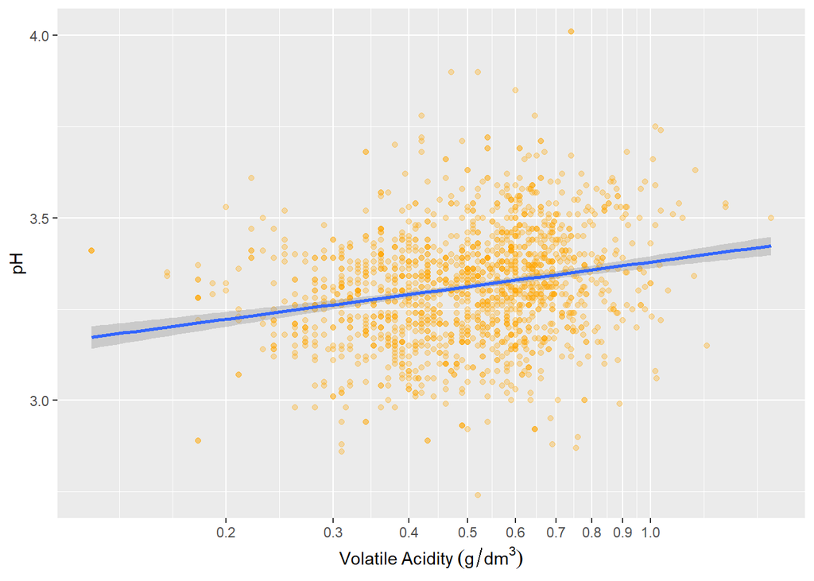

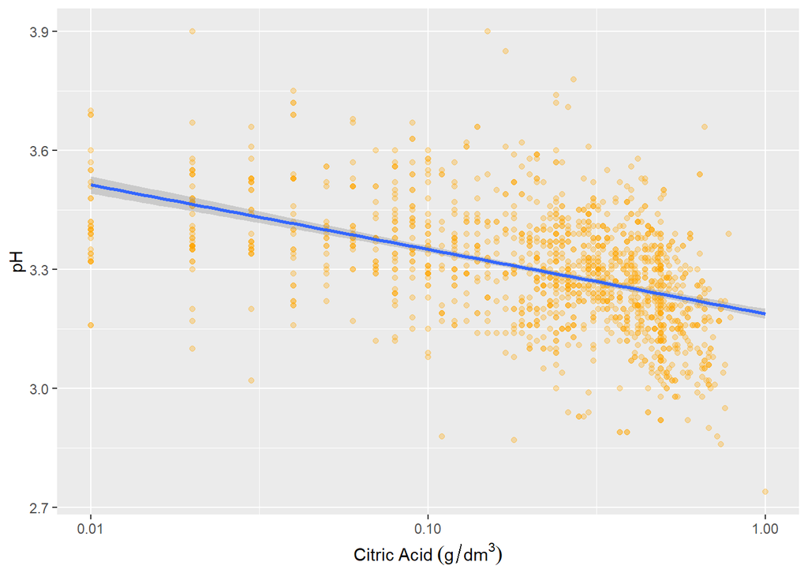

These three plots reminds of the contradiction that we saw earlier. We noticed from plots earlier that Volatile acid and pH has positive correlation while acidity has negative correlation with pH.

This maybe due to Simpsons Paradox.According to Wikipedia

“Simpson’s paradox, or the Yule-Simpson effect, is a phenomenon in probability and statistics, in which a trend appears in several different groups of data but disappears or reverses when these groups are combined. It is sometimes given the descriptive title reversal paradox or amalgamation paradox.”

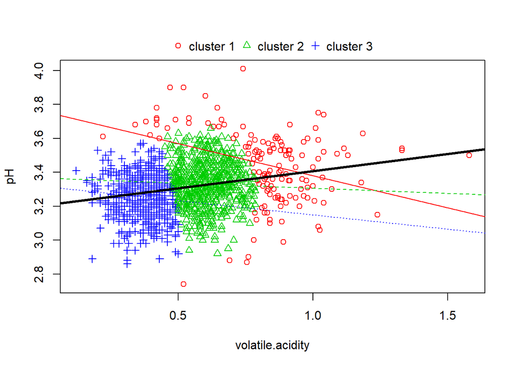

This plot shows there is Simpsons paradox with this data set. We can see both positive and negative correlation in the clusters.

Investigating further…..

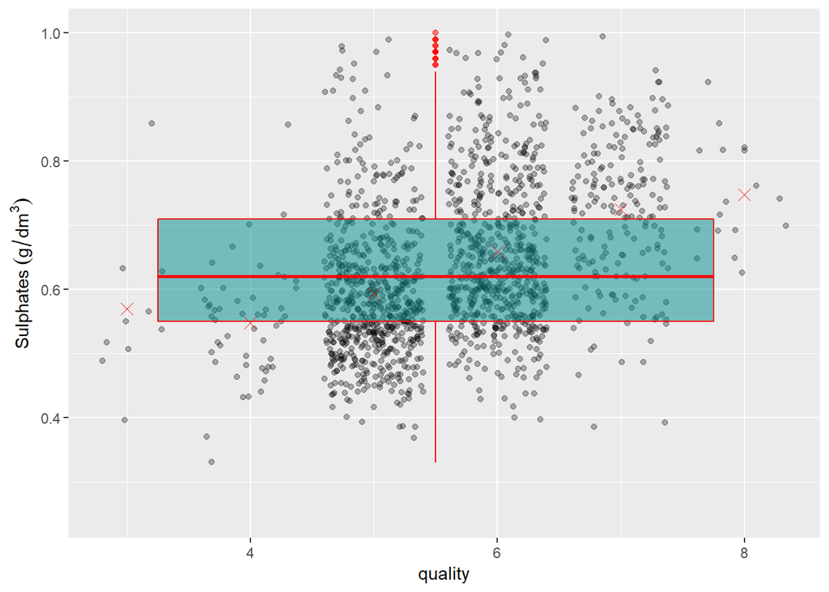

There seems to be a positive correlation between quality and sulphates. So better wines have higher amounts of sulphates.

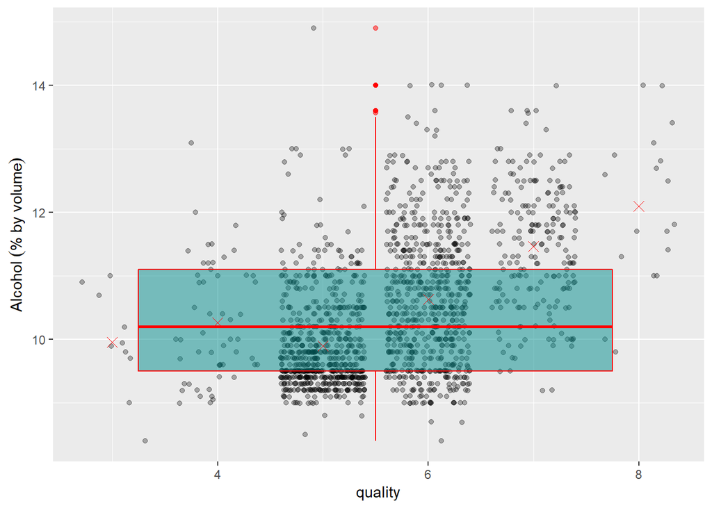

Again we see a positive correlation between quality and alcohol. The plot shows that better wines have higher alcohol in it. Please note, this plot also has a lot of outliers. This outliers may tip the scales in favor of a positive correlation.

### Plotting a Linear Model

```
##
## Call:
## lm(formula = as.numeric(quality) ~ alcohol, data = df_rw)
##
## Residuals:
##     Min      1Q  Median      3Q     Max
## -2.8442 -0.4112 -0.1690  0.5166  2.5888
##
## Coefficients:
##             Estimate Std. Error t value Pr(>|t|)
## (Intercept)  1.87497    0.17471   10.73   <2e-16 ***
## alcohol      0.36084    0.01668   21.64   <2e-16 ***
## ---
## Signif. codes:  0 '***' 0.001 '**' 0.01 '*' 0.05 '.' 0.1 ' ' 1
##
## Residual standard error: 0.7104 on 1597 degrees of freedom
## Multiple R-squared:  0.2267, Adjusted R-squared:  0.2263
## F-statistic: 468.3 on 1 and 1597 DF,  p-value: < 2.2e-16
```

The R squared values shows that Alcohol influences about 22 percent of the quality. The rest is influenced by other variables. We can estimate better by calculating the correlation test for other variables as well.

[output not shown]

From the results,it seems that the following variables have a positive correlation compared to quality of wine.

Alcohol, Sulphates, Citric Acid

Plotting against variable density/pH with “total.acidity”"

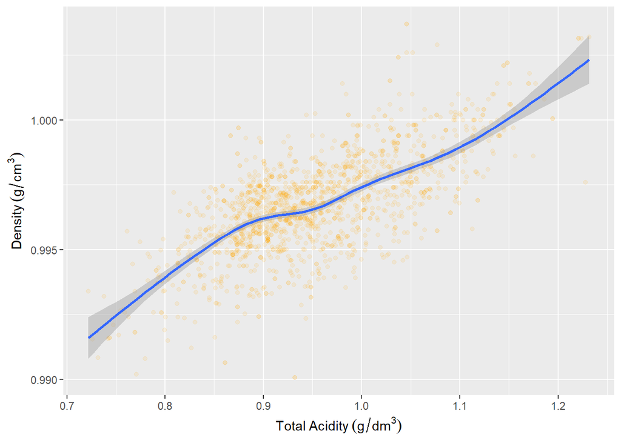

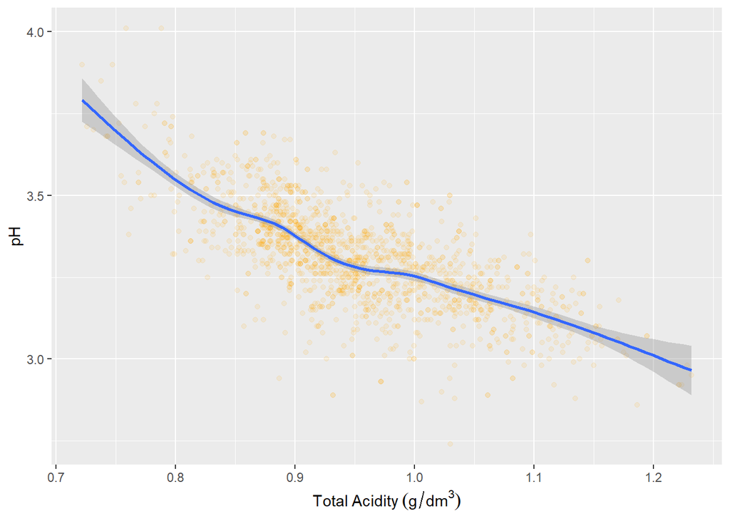

The two plots show that there is a linear relationship between density/total.acidity and pH/total.acidity.

## Analysis of Bivariate Plots

### Observations

Quality is not affected with changes in Residual sugar. Quality is not affected with changes in Fixed Acidity. Quality has a negative correlation with volatile acidity Citric acid has a positive correlation with quality. Alcohol has a positive correlation with quality. The R-squared value indicates that alcohol influences only about 22 % of the quality. Chlorides has a weak correlation with quality. Acidity has positive correlation with quality.

### Unique Scenario (Contradiction)

The positive correlation between pH and volatile acidity is a contradiction. We noticed from plots earlier that Volatile acid and pH has positive correlation while acidity has negative correlation with pH.